# Advanced `ggplot2` Homework

# 1 Homework Info

## 1.1 Learning Objectives

- Practice making plots with ggplot2
- Create your own theme and use it with plots

## 1.2 Background

QikBit is a start-up company producing low cost fitness trackers. Their flagship product, the KwikBit Unit1 (spot the mistake on the patent form) reproduces the functionality of the best-in-class commercial fitness trackers, but is cheap to make. They are currently preparing to pitch to a potential investor and require a selection of charts to include in their presentation and promotional materials.

## 1.3 Data

The data for this assignment is provided in the `CodeClanData` package.

- `qb_revenue_breakdown`
- `qb_monthly_sales`
- `qb_competitors`
- `qb_device_data`

Take a little time before you start to familiarise yourself with the data.

# 2 MVP

## 2.1 Part 1

**Question 1.**  
Take the data in the dataset `qb_revenue_breakdown` and make a stacked bar chart showing the sources of revenue across the two years in the dataset.

**Questino 2.**  
Make a line chart showing monthly sales of the “flagship product” - the ‘KwikBit Unit 1’ - over the last year. This data is inside `qb_monthly_sales`, but you will need to use `filter()` or `subset()` (base `R)`.

**Question 3.**  
Make a line chart showing monthly revenue and costs over the last year. This data is also in `qb_monthly_sales`.

**Question 4.**  
Show annual sales of personal fitness trackers over the last 5 years broken down by company as a ribbon plot (use `geom_area`). This data is in `qb_competitors`.

**Question 5.**  
Now show the sales from the four competitors as a line graph. Include an extra layer that shows the data points used to make the lines.

**Question 6.**  
Now the company wants to compare the number of steps that their device counts vs. their competitors. Make a line graph of the number of steps throughout time, and use faceting to compare between companies and people. The data for this is in `qb_device_data`.

## 2.2 Part 2

**Question 1.**  
Take the plots that you produced in part one and now polish them by:

1. Adding appropriate labels
2. Changing the scales and coordinates when appropriate.
3. Applying a unified theme, which is described below:
- Graphs should have white backgrounds, and use colour sparingly.
- There should be faint grid lines.
- Font sizes should be ~12pt although titles should be slightly larger and axis labels can be slightly smaller.
- All plots should use colours from the following company colour scheme.

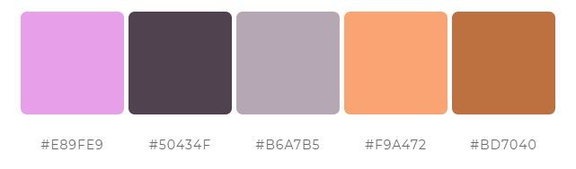

```r
col_scheme <- c("#E89FE9", "#50434F", "#B6A7B5", "#F9A472", "#BD7040")
```

# 3 Extension